# Multiple Linear Regression Example

We First load our file and set CAT.MEDV to NULL as they are going to be measuring the same thing. That would be addressed in Logististic regression.

```r
MLRboston <- read.csv("BostonHousing.csv", header = T)
MLRboston$CAT..MEDV <- NULL
```

Data scientists split their data so as to fit a prediction to a model and validate this prediction on a validation model. This reduces data discrepancies and lowers the chances of overfitting or underfitting your model.

```r
t.index <- sample(row.names(MLRboston), 0.6*dim(MLRboston)[1])
v.index <- setdiff(row.names(MLRboston), t.index)
t.df <- MLRboston[t.index, ]
v.df <- MLRboston[v.index, ]
```

Then we fit a regression line to the train dataset and use the summary() to summarize the results.

```r
boston.lm <- lm(MEDV ~ CRIM + CHAS + RM, data = t.df)
summary(boston.lm)
```

```
Call:
lm(formula = MEDV ~ CRIM + CHAS + RM, data = t.df)

Residuals:
     Min       1Q   Median       3Q      Max
-16.7000  -2.8216  -0.5506   2.4679  28.2729

Coefficients:
             Estimate Std. Error t value Pr(>|t|)
(Intercept) -29.08725    3.24711  -8.958  < 2e-16 ***
CRIM         -0.29574    0.04233  -6.986 1.85e-11 ***
CHAS          3.32348    1.29355   2.569   0.0107 *
RM            8.32960    0.51339  16.225  < 2e-16 ***
---
Signif. codes:  0 ‘***’ 0.001 ‘**’ 0.01 ‘*’ 0.05 ‘.’ 0.1 ‘ ’ 1

Residual standard error: 5.814 on 299 degrees of freedom
Multiple R-squared:  0.5669,    Adjusted R-squared:  0.5625
F-statistic: 130.4 on 3 and 299 DF,  p-value: < 2.2e-16
```

There are many ways in which you can create a correlation matrix. R has a preloaded function but we can also use ggplot2 library. Let us go through the steps: 1) I rounded up to 2 decimal places using the round() function. 2)Melted the new data frame

```r
library(ggplot2)
library(reshape)
cor.MLR <- round(cor(MLRboston),2)
Melted.MLR <- melt(cor.MLR)
```

using ggplot2 lets make a correlation matrix

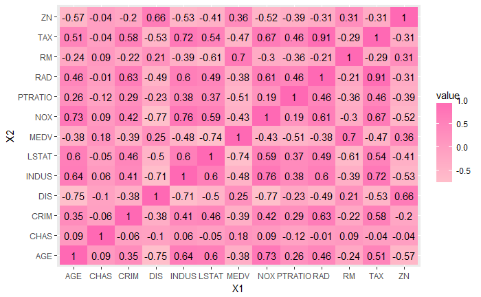

```r
ggplot(Melted.MLR, aes(x=X1, y=X2, fill = value)) +
  geom_tile() +
  scale_fill_gradient(low = 'pink', high = 'hotpink') +
  geom_text(aes(x=X1, y=X2, label=value))
```

let us make a linear model for all variables, remember we only used select variables.

```r
MLRboston.lm <- lm(MEDV ~ ., data = t.df)
summary(MLRboston)
```

```
      CRIM                ZN             INDUS            CHAS              NOX               RM
 Min.   : 0.00632   Min.   :  0.00   Min.   : 0.46   Min.   :0.00000   Min.   :0.3850   Min.   :3.561
 1st Qu.: 0.08204   1st Qu.:  0.00   1st Qu.: 5.19   1st Qu.:0.00000   1st Qu.:0.4490   1st Qu.:5.886
 Median : 0.25651   Median :  0.00   Median : 9.69   Median :0.00000   Median :0.5380   Median :6.208
 Mean   : 3.61352   Mean   : 11.36   Mean   :11.14   Mean   :0.06917   Mean   :0.5547   Mean   :6.285
 3rd Qu.: 3.67708   3rd Qu.: 12.50   3rd Qu.:18.10   3rd Qu.:0.00000   3rd Qu.:0.6240   3rd Qu.:6.623
 Max.   :88.97620   Max.   :100.00   Max.   :27.74   Max.   :1.00000   Max.   :0.8710   Max.   :8.780
      AGE              DIS              RAD              TAX           PTRATIO          LSTAT
 Min.   :  2.90   Min.   : 1.130   Min.   : 1.000   Min.   :187.0   Min.   :12.60   Min.   : 1.73
 1st Qu.: 45.02   1st Qu.: 2.100   1st Qu.: 4.000   1st Qu.:279.0   1st Qu.:17.40   1st Qu.: 6.95
 Median : 77.50   Median : 3.207   Median : 5.000   Median :330.0   Median :19.05   Median :11.36
 Mean   : 68.57   Mean   : 3.795   Mean   : 9.549   Mean   :408.2   Mean   :18.46   Mean   :12.65
 3rd Qu.: 94.08   3rd Qu.: 5.188   3rd Qu.:24.000   3rd Qu.:666.0   3rd Qu.:20.20   3rd Qu.:16.95
 Max.   :100.00   Max.   :12.127   Max.   :24.000   Max.   :711.0   Max.   :22.00   Max.   :37.97
      MEDV
 Min.   : 5.00
 1st Qu.:17.02
 Median :21.20
 Mean   :22.53
 3rd Qu.:25.00
 Max.   :50.00
```

```r
boston.lm.step <- step(MLRboston.lm, direction = "forward")
```

```
Start:  AIC=909.13
MEDV ~ CRIM + ZN + INDUS + CHAS + NOX + RM + AGE + DIS + RAD +
    TAX + PTRATIO + LSTAT
```

```r
summary(boston.lm.step)
```

```
Call:
lm(formula = MEDV ~ CRIM + ZN + INDUS + CHAS + NOX + RM + AGE +
    DIS + RAD + TAX + PTRATIO + LSTAT, data = t.df)

Residuals:
     Min       1Q   Median       3Q      Max
-10.3099  -2.7387  -0.2886   1.6479  16.1015

Coefficients:
              Estimate Std. Error t value Pr(>|t|)
(Intercept)  42.668953   5.872308   7.266 3.44e-12 ***
CRIM         -0.103899   0.043743  -2.375  0.01819 *
ZN            0.049504   0.016258   3.045  0.00254 **
INDUS         0.014261   0.076236   0.187  0.85174
CHAS          3.002730   1.029301   2.917  0.00381 **
NOX         -20.462021   4.468934  -4.579 6.95e-06 ***
RM            3.468802   0.524159   6.618 1.76e-10 ***
AGE           0.007300   0.015361   0.475  0.63496
DIS          -1.485686   0.231151  -6.427 5.32e-10 ***
RAD           0.256851   0.078656   3.265  0.00122 **
TAX          -0.011109   0.004514  -2.461  0.01444 *
PTRATIO      -0.933089   0.153283  -6.087 3.63e-09 ***
LSTAT        -0.547454   0.061885  -8.846  < 2e-16 ***
---
Signif. codes:  0 ‘***’ 0.001 ‘**’ 0.01 ‘*’ 0.05 ‘.’ 0.1 ‘ ’ 1

Residual standard error: 4.39 on 290 degrees of freedom
Multiple R-squared:  0.7606,    Adjusted R-squared:  0.7506
F-statistic: 76.76 on 12 and 290 DF,  p-value: < 2.2e-16
```

Finally let us check the accuracy of the model. to use this function, you would need the “forecast” library. We used the validation set to check the accuracy of the model and not the train data set.

```r
library(forecast)
boston.lm.step.pred <- predict(boston.lm.step, v.df)
accuracy(boston.lm.step.pred, v.df$MEDV)
```

```
                ME     RMSE      MAE       MPE     MAPE
Test set 0.5677371 5.354439 3.591311 -1.407126 16.42456
```